# Lab 5 Demo: Discrete-Event Simulation

This demo prepares for Lab 5 using **Chapter 7: Discrete-Event Simulation**. It covers:

1. events, state, and why the simulation clock jumps from event to event;
2. exponential interarrival and service times, and the difference between a **rate** and a **mean**;
3. the event-scheduling algorithm with state $(t,N,t_A,t_D)$;
4. the first-come-first-served (FCFS) shortcut, and why it gives the same event times for one server;
5. output measures: waiting time, time in system, utilisation, and queue length;
6. M/M/1 theory: $\rho$, stability, and the steady-state formulas $W$ and $W_q$;
7. why one run is one history, and why a run that starts empty differs from steady state;
8. replications, a confidence interval for the mean wait, and paired comparisons with common random numbers.

The demo uses a campus **help desk**. You learn each method here, and in the lab you apply it to the coffee shop yourself.

### How this demo maps to Lab 5

| Demo | Theory | Lab 5 part |
| --- | --- | --- |
| 1 | Rates versus means, $\rho$ | B (rate-to-mean conversion, trial checks) |
| 2 | Event list by hand, then as a function | A (event logic) |
| 3 | FCFS shortcut $\texttt{start}_i=\max(\texttt{arrival}_i,\texttt{end}_{i-1})$ | A, B (`simulate_mm1`) |
| 4 | Output measures and the event history | C |
| 5–6 | M/M/1 theory, scenarios, theory column | B (trials), D |
| 7 | One run is one history; empty start; terminating versus steady state | B (five seeds), D (questions 2–3) |
| 8 | Replications, confidence interval, common random numbers | E |
| 9 | Writing a recommendation | Recommendation and reflection |

## Part 0: Setup

```python
import numpy as np
import pandas as pd
import matplotlib.pyplot as plt

DEMO_SEED = 6901
```

## Theory 1: What is a discrete-event simulation?

### Why we need it

Lab 4 simulated **one number per day** (profit). A queue is different: what happens to one visitor depends on everyone who arrived before. We need to follow the system **through time**.

A naive approach updates the system every second. But at a help desk almost nothing happens most of the time: the state changes only when someone **arrives** or someone **finishes service**. A **discrete-event simulation (DES)** jumps the clock directly from one event to the next:

$$ 0\longrightarrow T_1\longrightarrow T_2\longrightarrow T_3\longrightarrow\cdots $$

Between events, time passes but the state is constant.

| Word | Meaning | Help-desk example |
| --- | --- | --- |
| **event** | an instant at which the state can change | a visitor arrives; a service finishes |
| **state** | what we must know to continue the simulation | number in system $N$, next arrival time $t_A$, next departure time $t_D$ |
| **counter** | a running total updated at events | number of arrivals so far $N_A$, number of departures so far $N_D$ |
| **output measure** | what we report at the end | average wait, longest wait, utilisation, maximum queue length |

**Questions:** For each item, is it an event, a state variable, a counter, or an output measure?

1. A visitor finishes being helped.
2. The number of visitors currently at the desk.
3. The average waiting time over the whole run.
4. The total number of visitors who have arrived so far.
5. The scheduled time of the next arrival.

## Theory 2: Exponential times — rates versus means

### The model

In an M/M/1 queue, the times between arrivals are independent exponential random variables with **rate** $\lambda$, and service times are independent exponential random variables with **rate** $\mu$.

If $T\sim\mathrm{Exponential}(\text{rate }\lambda)$, then

$$ \mathbb P(T>t)=e^{-\lambda t},\qquad \mathbb E[T]=\frac1\lambda . $$

With $\lambda$ **per hour**, the mean gap is $1/\lambda$ hours, which is $60/\lambda$ **minutes**.

### Why exponential? The memoryless property

$$ \mathbb P(T>s+t\mid T>s)=\frac{e^{-\lambda(s+t)}}{e^{-\lambda s}}=e^{-\lambda t}=\mathbb P(T>t). $$

However long a service has already lasted, the remaining time has the same distribution as a fresh one. So to predict the future we only need **how many** people are at the desk, not how long each has been there. This is why the state of an M/M/1 queue is so small.

### What NumPy expects

`rng.exponential(scale, size)` takes the **mean** (`scale`), **not** the rate. This is the same trap as Lab 3 Part B.

| Quantity | Formula | Help desk ($\lambda=5$, $\mu=9$ per hour) |
| --- | --- | --- |
| mean gap between arrivals | $60/\lambda$ minutes | 12 minutes |
| mean service time | $60/\mu$ minutes | 6.67 minutes |
| traffic intensity | $\rho=\lambda/\mu$ | 0.556 |

**Question:** What is the mean of `rng.exponential(5, size=100_000)`, and what arrival rate would that represent?

## Demo 1: From hourly rates to NumPy scales

### Step 1 — the rates and the means

```python
arrival_rate = 5.0      # visitors per hour (lambda)
service_rate = 9.0      # visitors per hour that one adviser can serve (mu)

mean_gap = 60 / arrival_rate          # minutes between arrivals, on average
mean_service = 60 / service_rate      # minutes per service, on average
rho = arrival_rate / service_rate

print("mean gap (min)     :", mean_gap)
print("mean service (min) :", mean_service)
print("rho                :", rho)
```

```
mean gap (min)     : 12.0
mean service (min) : 6.666666666666667
rho                : 0.5555555555555556
```

### Step 2 — draw a few gaps and look at them

```python
rng = np.random.default_rng(DEMO_SEED)
gaps = rng.exponential(mean_gap, size=5)      # scale = MEAN in minutes
gaps
```

```
array([ 0.39489742,  2.07496504, 23.15521065,  6.86210812,  2.42823609])
```

Most gaps are shorter than the mean and a few are much longer: the exponential distribution is right-skewed.

### Step 3 — check the mean, and see the mistake

```python
check_rng = np.random.default_rng(DEMO_SEED)
correct = check_rng.exponential(mean_gap, size=100_000)       # scale = 60 / rate
mistake = check_rng.exponential(arrival_rate, size=100_000)    # WRONG: the rate passed as the mean

print(f"correct: sample mean gap = {correct.mean():.2f} min  ->  {60 / correct.mean():.2f} arrivals per hour")
print(f"mistake: sample mean gap = {mistake.mean():.2f} min  ->  {60 / mistake.mean():.2f} arrivals per hour")
```

```
correct: sample mean gap = 11.97 min  ->  5.01 arrivals per hour
mistake: sample mean gap = 5.00 min  ->  12.01 arrivals per hour
```

The mistake produces about 12 arrivals per hour instead of 5. If the same mistake is made for the service rate, the means become 5 and 9 minutes, so the effective $\rho$ becomes $5/9$ **inverted**: $9/5=1.8$. A stable desk turns into an overloaded one, or the reverse.

**Lab link:** Lab 5 Part B has a trial check designed to catch exactly this error.

## Theory 3: The event-scheduling algorithm (Chapter 7)

The state of the single-server queue is

$$ (t,\ N,\ t_A,\ t_D), $$

where $t$ is the clock, $N$ the number in the system (waiting plus in service), $t_A$ the scheduled next arrival and $t_D$ the scheduled next departure. The **event list** has only these two entries, and the simulation always processes the one with the smaller time.

### Pseudocode: M/M/1 event scheduling (Chapter 7)

1. **Initialisation.** Set $t=0$, $N=0$, $t_A=-\frac1\lambda\ln U_1$, $t_D=\infty$.
2. **Determine next event.** If $t_A<t_D$, process an arrival. Otherwise process a departure.
3. **Arrival event.**
   - Set $t\leftarrow t_A$.
   - Set $N\leftarrow N+1$.
   - Schedule the next arrival: $t_A\leftarrow t-\frac1\lambda\ln U$.
   - If $N=1$, the server was idle, so schedule a departure: $t_D\leftarrow t-\frac1\mu\ln U'$.
4. **Departure event.**
   - Set $t\leftarrow t_D$.
   - Set $N\leftarrow N-1$.
   - If $N>0$, schedule the next service completion: $t_D\leftarrow t-\frac1\mu\ln U$.
   - If $N=0$, set $t_D\leftarrow\infty$.
5. **Record statistics.** Update queue length, waiting time, and utilisation statistics.
6. Repeat until the stopping rule is satisfied.

### From pseudocode to Python

- $-\frac1\lambda\ln U$ is an exponential draw with rate $\lambda$ (inverse transform, Chapter 5). In code it is `arrival_rng.exponential(mean_gap)` with `mean_gap = 60 / arrival_rate` minutes; similarly `service_rng.exponential(mean_service)` for $-\frac1\mu\ln U'$.
- $t_D=\infty$ is `np.inf`.
- Step 2 is `if t_A < t_D: ... else: ...`. When the two times are equal, the departure is processed first — the same convention as Lab 5.
- Every code cell below is labelled with the step number it implements.

**Common mistake (Chapter 7).** Writing $t_A=-\ln(U)/\lambda$ every time, that is, $t_A=\text{new gap}$, instead of $t_A=t+\text{new gap}$. A gap is a *duration*; $t_A$ is a *clock time*.

## Demo 2: The event list by hand

### Step 0 — two random-number streams

The pseudocode uses $U$ for arrivals and $U'$ for services. We give them **separate generators**: one for gaps and one for service times. Then visitor $k$ always receives the $k$-th gap and the $k$-th service time, whatever order the events happen in. Demo 8 shows why this matters.

We will restart these two streams several times, so we write a small helper once.

```python
def make_streams(seed):
    # One generator for gaps (U) and one for service times (U').
    # NEW: SeedSequence(seed).spawn(2) makes two independent child seeds.
    arrival_seq, service_seq = np.random.SeedSequence(seed).spawn(2)
    return np.random.default_rng(arrival_seq), np.random.default_rng(service_seq)


arrival_rng, service_rng = make_streams(DEMO_SEED)    # tuple unpacking, as in Lab 4
```

### Step 1 — initialise the state

```python
# Step 1. Initialisation
t = 0.0
N = 0
t_A = arrival_rng.exponential(mean_gap)    # first arrival time = first gap (the clock starts at 0)
t_D = np.inf                               # NEW: np.inf is "infinity": no departure is scheduled while the desk is idle

print(f"t = {t:.2f}, N = {N}, t_A = {t_A:.2f}, t_D = {t_D}")
```

```
t = 0.00, N = 0, t_A = 15.09, t_D = inf
```

**Step 2. Determine next event.** $t_A<t_D=\infty$, so it must be an arrival.

### Step 2 — event 1: an arrival

```python
# Step 3. Arrival event
t = t_A                                          # jump the clock to the event time
N = N + 1                                        # one more visitor in the system
t_A = t + arrival_rng.exponential(mean_gap)      # schedule the NEXT arrival: clock time = now + gap
# N == 1, so the server was idle: schedule a departure
service_time = service_rng.exponential(mean_service)
t_D = t + service_time

print(f"service time drawn = {service_time:.2f}")
print(f"t = {t:.2f}, N = {N}, t_A = {t_A:.2f}, t_D = {t_D:.2f}")
```

```
service time drawn = 1.63
t = 15.09, N = 1, t_A = 29.38, t_D = 16.72
```

**Step 2 again. Determine next event:** compare $t_A$ and $t_D$ above.

### Step 3 — event 2: a departure

```python
# Step 4. Departure event
t = t_D                      # jump to the departure time
N = N - 1                    # the visitor leaves
# N == 0, so nobody is waiting: the desk becomes idle
t_D = np.inf

print(f"t = {t:.2f}, N = {N}, t_A = {t_A:.2f}, t_D = {t_D}")
```

```
t = 16.72, N = 0, t_A = 29.38, t_D = inf
```

### Step 4 — the general rule in one cell

Events 1 and 2 used straight-line code because we knew which event came next. The general rule must *decide* (Step 2). We write Steps 2–4 once with `if ... else` and run the same cell for events 3 and 4.

```python
# ---- event 3 ----
# Step 2. Determine next event
if t_A < t_D:
    # Step 3. Arrival event
    t = t_A
    N = N + 1
    t_A = t + arrival_rng.exponential(mean_gap)
    if N == 1:          # server was idle: schedule a departure
        t_D = t + service_rng.exponential(mean_service)
    event_type = "arrival"
else:
    # Step 4. Departure event
    t = t_D
    N = N - 1
    if N > 0:           # schedule the next service completion
        t_D = t + service_rng.exponential(mean_service)
    else:
        t_D = np.inf
    event_type = "departure"

print(f"{event_type:9s}: t = {t:.2f}, N = {N}, t_A = {t_A:.2f}, t_D = {t_D:.2f}")
```

```
arrival  : t = 29.38, N = 1, t_A = 36.63, t_D = 31.67
```

```python
# ---- event 4: the SAME code, copied unchanged ----
if t_A < t_D:
    t = t_A
    N = N + 1
    t_A = t + arrival_rng.exponential(mean_gap)
    if N == 1:
        t_D = t + service_rng.exponential(mean_service)
    event_type = "arrival"
else:
    t = t_D
    N = N - 1
    if N > 0:
        t_D = t + service_rng.exponential(mean_service)
    else:
        t_D = np.inf
    event_type = "departure"

print(f"{event_type:9s}: t = {t:.2f}, N = {N}, t_A = {t_A:.2f}, t_D = {t_D:.2f}")
```

```
departure: t = 31.67, N = 0, t_A = 36.63, t_D = inf
```

**Question:** Between event 2 and event 3, what was the state of the desk? Did the simulation need to do anything during that time?

### Python lesson: the `while` loop

A `for` loop repeats a **known** number of times. A `while` loop repeats **as long as a condition is true** — useful when we do not know in advance how many events there will be.

```python
count = 3
while count > 0:          # NEW: while condition: repeats the indented block while the condition is True
    print("count =", count)
    count = count - 1     # without this line the condition would stay True for ever
print("finished")
```

```
count = 3
count = 2
count = 1
finished
```

### Now the loop: the first ten events, with an event log

The loop body is exactly the event-3 cell. Two pseudocode steps that we skipped by hand now appear: **Step 5** (record: here, one row of an event log per event) and **Step 6** (the stopping rule: here, ten events). We restart both streams so that the first four rows reproduce the hand calculation.

```python
arrival_rng, service_rng = make_streams(DEMO_SEED)

# Step 1. Initialisation
t, N = 0.0, 0                                    # NEW: a, b = x, y assigns two variables at once
t_A = arrival_rng.exponential(mean_gap)
t_D = np.inf
event_log = []

# Step 6. Stopping rule: ten events
while len(event_log) < 10:
    # Step 2. Determine next event
    if t_A < t_D:
        # Step 3. Arrival event
        t = t_A
        N = N + 1
        t_A = t + arrival_rng.exponential(mean_gap)
        if N == 1:
            t_D = t + service_rng.exponential(mean_service)
        event_type = "arrival"
    else:
        # Step 4. Departure event
        t = t_D
        N = N - 1
        if N > 0:
            t_D = t + service_rng.exponential(mean_service)
        else:
            t_D = np.inf
        event_type = "departure"
    # Step 5. Record
    event_log.append({"event": len(event_log) + 1, "type": event_type,
                      "t": t, "N": N, "t_A": t_A, "t_D": t_D})

pd.DataFrame(event_log).round(2)
```

|  | event | type | t | N | t_A | t_D |
| --- | --- | --- | --- | --- | --- | --- |
| 0 | 1 | arrival | 15.09 | 1 | 29.38 | 16.72 |
| 1 | 2 | departure | 16.72 | 0 | 29.38 | inf |
| 2 | 3 | arrival | 29.38 | 1 | 36.63 | 31.67 |
| 3 | 4 | departure | 31.67 | 0 | 36.63 | inf |
| 4 | 5 | arrival | 36.63 | 1 | 39.84 | 40.12 |
| 5 | 6 | arrival | 39.84 | 2 | 42.46 | 40.12 |
| 6 | 7 | departure | 40.12 | 1 | 42.46 | 51.77 |
| 7 | 8 | arrival | 42.46 | 2 | 44.27 | 51.77 |
| 8 | 9 | arrival | 44.27 | 3 | 53.87 | 51.77 |
| 9 | 10 | departure | 51.77 | 2 | 53.87 | 57.92 |

**Check:** rows 1–4 equal the four hand-calculated events. Rows 5–10 show something new: at event 6 an arrival happens while the desk is busy, so $N$ reaches 2 — somebody is **waiting**.

**Note.** Events 1–4 alternate arrival, departure, arrival, departure (clock times about 15.09, 16.72, 29.38, 31.67 minutes). From event 5 on, arrivals at about 36.63, 39.84, 42.46 and 44.27 come faster than services finish, and $N$ reaches 3 at event 9.

The log records the state after each event, but not each visitor's waiting time. For that, Step 5 must record, for every visitor, when they arrived, started service and left.

### Record every visitor: 12 visitors

The algorithm is unchanged: Steps 1–4 are the event-3 cell. We add only the **counters** from the Chapter 7 table and the **recording** in Step 5:

- $N_A$ = number of arrivals so far, $N_D$ = number of departures so far, so $N=N_A-N_D$.
- One server serves in arrival order, so the arriving visitor is visitor $N_A$, the departing visitor is visitor $N_D$, and the visitor who starts service is always the next one, visitor $N_D+1$.
- So recording is just `append`: the $k$-th arrival time, the $k$-th start and the $k$-th departure all belong to visitor $k$.

**Stopping rule (Step 6):** stop scheduling arrivals after the 12th visitor, and stop the loop when all 12 have left ($N_D=12$).

```python
arrival_rng, service_rng = make_streams(DEMO_SEED)
n_visitors = 12

# Step 1. Initialisation
t, N = 0.0, 0
N_A, N_D = 0, 0                    # counters: arrivals, departures so far
t_A = arrival_rng.exponential(mean_gap)
t_D = np.inf
arrival, service, start, end = [], [], [], []   # entry k-1 = visitor k

# Step 6. Stopping rule: repeat until all visitors have left
while N_D < n_visitors:
    # Step 2. Determine next event
    if t_A < t_D:
        # Step 3. Arrival event
        t = t_A
        N = N + 1
        N_A = N_A + 1
        arrival.append(t)          # Step 5. record: visitor N_A arrives
        if N_A < n_visitors:
            t_A = t + arrival_rng.exponential(mean_gap)
        else:
            t_A = np.inf           # last visitor has arrived
        if N == 1:                 # server was idle: schedule a departure
            service_time = service_rng.exponential(mean_service)
            t_D = t + service_time
            start.append(t)        # Step 5. record: visitor N_D + 1 starts
            service.append(service_time)
    else:
        # Step 4. Departure event
        t = t_D
        N = N - 1
        N_D = N_D + 1
        end.append(t)              # Step 5. record: visitor N_D leaves
        if N > 0:                  # schedule the next service completion
            service_time = service_rng.exponential(mean_service)
            t_D = t + service_time
            start.append(t)        # Step 5. record: visitor N_D + 1 starts
            service.append(service_time)
        else:
            t_D = np.inf

manual_trace = pd.DataFrame({"visitor": np.arange(1, n_visitors + 1),
                             "arrival": arrival, "service": service,
                             "start": start, "end": end})
manual_trace.round(2)
```

|  | visitor | arrival | service | start | end |
| --- | --- | --- | --- | --- | --- |
| 0 | 1 | 15.09 | 1.63 | 15.09 | 16.72 |
| 1 | 2 | 29.38 | 2.30 | 29.38 | 31.67 |
| 2 | 3 | 36.63 | 3.49 | 36.63 | 40.12 |
| 3 | 4 | 39.84 | 11.64 | 40.12 | 51.77 |
| 4 | 5 | 42.46 | 6.15 | 51.77 | 57.92 |
| 5 | 6 | 44.27 | 3.76 | 57.92 | 61.68 |
| 6 | 7 | 53.87 | 5.81 | 61.68 | 67.49 |
| 7 | 8 | 83.49 | 11.49 | 83.49 | 94.98 |
| 8 | 9 | 103.82 | 9.58 | 103.82 | 113.39 |
| 9 | 10 | 106.07 | 4.08 | 113.39 | 117.48 |
| 10 | 11 | 107.00 | 1.14 | 117.48 | 118.62 |
| 11 | 12 | 119.05 | 7.02 | 119.05 | 126.08 |

Two details:

- The service time is drawn **when service starts**, exactly as in the pseudocode, so a visitor who arrives to a busy desk gets their start time and service time later, at a departure.
- Recording by `append` uses the fact that **one server serves in arrival order**. With two advisers or priority visitors, the visitor who leaves is not always visitor $N_D$; the event list still works, but Step 5 would need to keep track of who is waiting.

### Only now: package the calculation into a function

> "All this function does is package the calculation we have just performed by hand."

```python
def simulate_help_desk(arrival_rate, service_rate, n_visitors,
                       arrival_rng, service_rng):
    # Event scheduling for an M/M/1 help desk (Chapter 7). Times in minutes.
    # One row per visitor: arrival, service, start, end, wait, time_in_system.
    mean_gap = 60 / arrival_rate
    mean_service = 60 / service_rate

    # Step 1. Initialisation
    t, N = 0.0, 0
    N_A, N_D = 0, 0
    t_A = arrival_rng.exponential(mean_gap)
    t_D = np.inf
    arrival, service, start, end = [], [], [], []

    # Step 6. Stopping rule
    while N_D < n_visitors:
        # Step 2. Determine next event
        if t_A < t_D:
            # Step 3. Arrival event
            t = t_A
            N = N + 1
            N_A = N_A + 1
            arrival.append(t)                          # Step 5. record
            if N_A < n_visitors:
                t_A = t + arrival_rng.exponential(mean_gap)
            else:
                t_A = np.inf
            if N == 1:
                service_time = service_rng.exponential(mean_service)
                t_D = t + service_time
                start.append(t)                        # Step 5. record
                service.append(service_time)
        else:
            # Step 4. Departure event
            t = t_D
            N = N - 1
            N_D = N_D + 1
            end.append(t)                              # Step 5. record
            if N > 0:
                service_time = service_rng.exponential(mean_service)
                t_D = t + service_time
                start.append(t)                        # Step 5. record
                service.append(service_time)
            else:
                t_D = np.inf

    visits = pd.DataFrame({"visitor": np.arange(1, n_visitors + 1),
                           "arrival": arrival, "service": service,
                           "start": start, "end": end})
    visits["wait"] = visits["start"] - visits["arrival"]
    visits["time_in_system"] = visits["end"] - visits["arrival"]
    return visits
```

### Map the function to the pseudocode

| Function part | Pseudocode step | Manual cells above |
| --- | --- | --- |
| `mean_gap = 60 / arrival_rate` | $-\frac1\lambda\ln U$ has mean $1/\lambda$ hours | Demo 1, Step 1 |
| `t, N = 0.0, 0`, `t_A = ...`, `t_D = np.inf` | 1. Initialisation | Step 1 |
| `if t_A < t_D:` | 2. Determine next event | Step 4 (events 3 and 4) |
| arrival block | 3. Arrival event | Step 2 |
| departure block | 4. Departure event | Step 3 |
| `arrival.append`, `start.append`, `end.append` | 5. Record statistics | the 12-visitor cell |
| `while N_D < n_visitors`; `t_A = np.inf` after the last arrival | 6. Stopping rule | the 12-visitor cell |
| `visits["wait"] = ...` | outputs computed from the records (Theory 5) | new |

The function is the 12-visitor cell, indented, with the rates and the number of visitors as arguments. The generators are **arguments**, not created inside: exactly as in the Lab 4 kiosk function, so that replications move forward through the streams.

**Test:** with fresh streams from the same seed, the function must reproduce the manual trace exactly.

```python
arrival_rng, service_rng = make_streams(DEMO_SEED)
trace = simulate_help_desk(arrival_rate, service_rate, 12, arrival_rng, service_rng)

print("identical to the manual trace?",
      np.allclose(trace[["arrival", "service", "start", "end"]], manual_trace[["arrival", "service", "start", "end"]]))
trace.round(2)
```

```
identical to the manual trace? True
```

|  | visitor | arrival | service | start | end | wait | time_in_system |
| --- | --- | --- | --- | --- | --- | --- | --- |
| 0 | 1 | 15.09 | 1.63 | 15.09 | 16.72 | 0.00 | 1.63 |
| 1 | 2 | 29.38 | 2.30 | 29.38 | 31.67 | 0.00 | 2.30 |
| 2 | 3 | 36.63 | 3.49 | 36.63 | 40.12 | 0.00 | 3.49 |
| 3 | 4 | 39.84 | 11.64 | 40.12 | 51.77 | 0.28 | 11.93 |
| 4 | 5 | 42.46 | 6.15 | 51.77 | 57.92 | 9.31 | 15.46 |
| 5 | 6 | 44.27 | 3.76 | 57.92 | 61.68 | 13.65 | 17.41 |
| 6 | 7 | 53.87 | 5.81 | 61.68 | 67.49 | 7.81 | 13.62 |
| 7 | 8 | 83.49 | 11.49 | 83.49 | 94.98 | 0.00 | 11.49 |
| 8 | 9 | 103.82 | 9.58 | 103.82 | 113.39 | 0.00 | 9.58 |
| 9 | 10 | 106.07 | 4.08 | 113.39 | 117.48 | 7.33 | 11.41 |
| 10 | 11 | 107.00 | 1.14 | 117.48 | 118.62 | 10.48 | 11.62 |
| 11 | 12 | 119.05 | 7.02 | 119.05 | 126.08 | 0.00 | 7.02 |

**Note.** Visitor 4 arrives at about 39.84 while visitor 3 is still being served (until 40.12), so visitor 4 waits about 0.28 minutes. Visitor 4 then has a long service (about 11.64 minutes), and visitors 5, 6 and 7 all wait behind it (about 9.31, 13.65 and 7.81 minutes). One long service delays everyone behind it — the Lab 3 point about long service times, now visible.

Visitor 6 waited 13.65 minutes, but that is one visitor in one run, not the expected waiting time at this desk.

## Theory 4: The FCFS shortcut for one server

### The idea

With **one server** and **first-come-first-served**, visitors are served in arrival order, and visitor $i$ can start only when

1. visitor $i$ has arrived, **and**
2. visitor $i-1$ has left.

So

$$ \boxed{\;\texttt{start}_i=\max(\texttt{arrival}_i,\ \texttt{end}_{i-1}),\qquad \texttt{end}_i=\texttt{start}_i+\texttt{service}_i\;} $$

with $\texttt{end}_0=0$. Subtracting $\texttt{arrival}_i$ gives the **Lindley recursion** for waiting times:

$$ \texttt{wait}_i=\max\big(0,\ \texttt{wait}_{i-1}+\texttt{service}_{i-1}-(\texttt{arrival}_i-\texttt{arrival}_{i-1})\big). $$

### Why it gives the same event times

The event list and the recursion follow the same rules: arrivals join at the back, the desk serves one visitor at a time, and the next visitor starts the moment the previous one leaves. Given the same arrival and service times, they must produce the same start and end times. The recursion simply computes them visitor by visitor instead of event by event.

### When the shortcut is not enough

The recursion relies on "one server, served in arrival order". With two advisers, priority visitors, visitors who give up and leave, or breaks, the order of service is no longer the order of arrival. Then there is no simple recursion, and we need the event list (with more event types and a record of who is waiting).

## Demo 3: Check the shortcut on the 12-visitor trace

Take the recorded arrival and service times and recompute start and end with the recursion.

### Visitors 1 and 2 by hand

```python
arr = trace["arrival"].to_numpy()
srv = trace["service"].to_numpy()

start_1 = max(arr[0], 0)                 # end_0 = 0: the desk starts empty
end_1 = start_1 + srv[0]
start_2 = max(arr[1], end_1)
end_2 = start_2 + srv[1]
print(f"visitor 1: start {start_1:.2f}, end {end_1:.2f}")
print(f"visitor 2: start {start_2:.2f}, end {end_2:.2f}")
```

```
visitor 1: start 15.09, end 16.72
visitor 2: start 29.38, end 31.67
```

### All 12 with a loop

```python
recursion_start = np.empty(len(arr))     # NEW: np.empty(k) makes an array of length k to be filled in
recursion_end = np.empty(len(arr))

previous_end = 0                         # end_0 = 0: the desk starts empty
for i in range(len(arr)):
    recursion_start[i] = max(arr[i], previous_end)
    recursion_end[i] = recursion_start[i] + srv[i]
    previous_end = recursion_end[i]

print("same start times as the event list?", np.allclose(recursion_start, trace["start"]))
print("same end times as the event list?  ", np.allclose(recursion_end, trace["end"]))
```

```
same start times as the event list? True
same end times as the event list?   True
```

**Lab link:** Lab 5 Part B asks you to write this recursion inside `simulate_mm1`. There, all gaps are generated first and all service times second, so visitor $i$ always gets the $i$-th draw of each — the same effect as our two streams.

**Question:** Why can the recursion use `max` but no `if` for "is the desk busy?"

## Theory 5: Output measures and their conventions

| Output | Definition | Notes |
| --- | --- | --- |
| waiting time of visitor $i$ | $\texttt{start}_i-\texttt{arrival}_i$ | time in the line only |
| time in system | $\texttt{end}_i-\texttt{arrival}_i$ | waiting plus service |
| average / longest wait | mean / maximum over visitors | the longest wait is a single extreme value, so it is very variable |
| utilisation | $\dfrac{\text{total service time}}{\text{last departure}-\text{first arrival}}$ | fraction of time the adviser is busy in that window |
| queue length $Q(t)$ | $\max(N(t)-1,\,0)$ | waiting visitors only, **excluding** the one in service |
| maximum queue length | $\max_t Q(t)$ | an integer |

Every one of these involves a **choice** (which window, whether the visitor in service counts, which event comes first at a tie). Other choices give other numbers, so the choice must be stated. Lab 5 uses exactly the conventions in this table, and processes a departure before an arrival at the same instant.

## Demo 4: Output measures for the 12 visitors

### Waiting times and time in system

```python
trace[["visitor", "arrival", "start", "end", "wait", "time_in_system"]].round(2)
```

|  | visitor | arrival | start | end | wait | time_in_system |
| --- | --- | --- | --- | --- | --- | --- |
| 0 | 1 | 15.09 | 15.09 | 16.72 | 0.00 | 1.63 |
| 1 | 2 | 29.38 | 29.38 | 31.67 | 0.00 | 2.30 |
| 2 | 3 | 36.63 | 36.63 | 40.12 | 0.00 | 3.49 |
| 3 | 4 | 39.84 | 40.12 | 51.77 | 0.28 | 11.93 |
| 4 | 5 | 42.46 | 51.77 | 57.92 | 9.31 | 15.46 |
| 5 | 6 | 44.27 | 57.92 | 61.68 | 13.65 | 17.41 |
| 6 | 7 | 53.87 | 61.68 | 67.49 | 7.81 | 13.62 |
| 7 | 8 | 83.49 | 83.49 | 94.98 | 0.00 | 11.49 |
| 8 | 9 | 103.82 | 103.82 | 113.39 | 0.00 | 9.58 |
| 9 | 10 | 106.07 | 113.39 | 117.48 | 7.33 | 11.41 |
| 10 | 11 | 107.00 | 117.48 | 118.62 | 10.48 | 11.62 |
| 11 | 12 | 119.05 | 119.05 | 126.08 | 0.00 | 7.02 |

```python
print("average wait           :", trace["wait"].mean())
print("longest wait           :", trace["wait"].max())
print("average time in system :", trace["time_in_system"].mean())
```

```
average wait           : 4.071424576219379
longest wait           : 13.65116612349928
average time in system : 9.746390172440668
```

### Utilisation: numerator and denominator separately

```python
busy_time = trace["service"].sum()
window = trace["end"].max() - trace["arrival"].iloc[0]       # first arrival to last departure
print(f"busy time = {busy_time:.2f} min,  window = {window:.2f} min,  utilisation = {busy_time / window:.3f}")
```

```
busy time = 68.10 min,  window = 110.99 min,  utilisation = 0.614
```

### Queue length: rebuild the event history

The visitor table stores times, not events. To get $N(t)$ we turn every arrival into a $+1$ event and every departure into a $-1$ event, sort them by time, and add them up.

**Step 1 — one row per event.**

```python
arrival_events = pd.DataFrame({"time": trace["arrival"], "delta": 1, "order": 1})
departure_events = pd.DataFrame({"time": trace["end"], "delta": -1, "order": 0})
events = pd.concat([arrival_events, departure_events])     # NEW: pd.concat stacks tables on top of each other
events.shape
```

```
(24, 3)
```

**Step 2 — sort by time.** The `order` column puts a departure (0) before an arrival (1) if they happen at the same instant.

```python
events = events.sort_values(["time", "order"], ignore_index=True)   # NEW: sort rows by time, then by order
events.head(8).round(2)
```

|  | time | delta | order |
| --- | --- | --- | --- |
| 0 | 15.09 | 1 | 1 |
| 1 | 16.72 | -1 | 0 |
| 2 | 29.38 | 1 | 1 |
| 3 | 31.67 | -1 | 0 |
| 4 | 36.63 | 1 | 1 |
| 5 | 39.84 | 1 | 1 |
| 6 | 40.12 | -1 | 0 |
| 7 | 42.46 | 1 | 1 |

**Step 3 — running total gives $N(t)$; subtract the visitor in service to get the queue.**

```python
events["number_in_system"] = events["delta"].cumsum()                     # NEW: .cumsum() = running total
events["queue_length"] = (events["number_in_system"] - 1).clip(lower=0)   # NEW: .clip(lower=0) replaces negatives by 0
events.head(12).round(2)
```

|  | time | delta | order | number_in_system | queue_length |
| --- | --- | --- | --- | --- | --- |
| 0 | 15.09 | 1 | 1 | 1 | 0 |
| 1 | 16.72 | -1 | 0 | 0 | 0 |
| 2 | 29.38 | 1 | 1 | 1 | 0 |
| 3 | 31.67 | -1 | 0 | 0 | 0 |
| 4 | 36.63 | 1 | 1 | 1 | 0 |
| 5 | 39.84 | 1 | 1 | 2 | 1 |
| 6 | 40.12 | -1 | 0 | 1 | 0 |
| 7 | 42.46 | 1 | 1 | 2 | 1 |
| 8 | 44.27 | 1 | 1 | 3 | 2 |
| 9 | 51.77 | -1 | 0 | 2 | 1 |
| 10 | 53.87 | 1 | 1 | 3 | 2 |
| 11 | 57.92 | -1 | 0 | 2 | 1 |

```
maximum queue length: 2
```

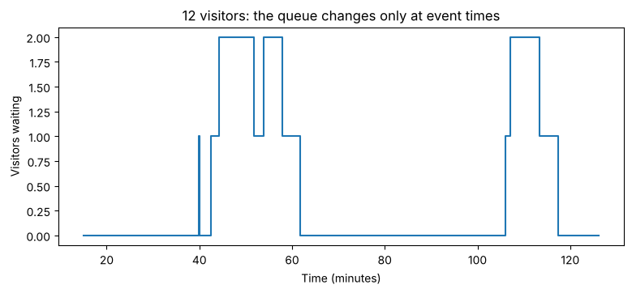

```python
print("maximum queue length:", events["queue_length"].max())

plt.figure(figsize=(9, 3.5))
plt.step(events["time"], events["queue_length"], where="post")   # NEW: plt.step draws a staircase; the value holds until the next event
plt.xlabel("Time (minutes)")
plt.ylabel("Visitors waiting")
plt.title("12 visitors: the queue changes only at event times")
plt.show()
```

**Note.** For the 12-visitor trace: average wait about 4.07 minutes, longest 13.65, average time in system about 9.75, utilisation about 0.614, maximum queue length 2.

The staircase shape *is* the DES idea: flat between events, jumps only at arrivals and departures.

**Lab link:** in Lab 5 the event reconstruction is provided (`event_history`) and you compute the five outputs in `summarise_queue`.

## Theory 6: M/M/1 theory — stability and steady state

### Traffic intensity and stability

$$ \rho=\frac{\lambda}{\mu} =\frac{\text{work arriving per hour}}{\text{work the server can do per hour}} . $$

- If $\rho<1$, the desk can keep up on average. Queues form by chance and then clear.
- If $\rho\ge1$, work arrives at least as fast as it can be done. The queue does not settle down; for $\rho>1$ it grows roughly linearly in time.

### Steady-state formulas (Chapter 7, valid only for $\rho<1$)

$$ \mathbb E[N]=\frac{\rho}{1-\rho},\qquad W=\frac{1}{\mu-\lambda},\qquad W_q=\frac{\rho}{\mu-\lambda}. $$

$W$ is the mean time in system and $W_q$ the mean wait in the queue, in **hours**; multiply by 60 for minutes.

### What "steady state" means

If the desk ran for ever, the distribution of $N(t)$ would settle down to a fixed long-run distribution. The formulas describe **that long-run regime**. They do **not** describe a desk that opens empty at 9:00, and they say nothing about one particular run. (Chapter 8 explains why the distribution settles, using Markov chains.)

**Question:** Compute $\rho$, $\mathbb E[N]$, $W$ and $W_q$ for the help desk ($\lambda=5$, $\mu=9$ per hour).

```python
def mm1_theory(arrival_rate, service_rate):
    # Steady-state M/M/1 values (times in minutes); NaN when the queue is unstable.
    if arrival_rate >= service_rate:
        return {"rho": arrival_rate / service_rate, "E[N]": np.nan, "W": np.nan, "W_q": np.nan}
    rho = arrival_rate / service_rate
    return {
        "rho": rho,
        "E[N]": rho / (1 - rho),
        "W": 60 / (service_rate - arrival_rate),
        "W_q": 60 * rho / (service_rate - arrival_rate),
    }


pd.Series(mm1_theory(arrival_rate, service_rate))
```

```
rho      0.555556
E[N]     1.250000
W       15.000000
W_q      8.333333
dtype: float64
```

## Demo 5: One long run versus the theory

Simulate 200 visitors, then 400 visitors, and compare the average wait with $W_q\approx8.33$ minutes.

```python
run_rows = []
for n in [200, 400]:
    arrival_rng, service_rng = make_streams(DEMO_SEED)      # fresh streams: the 200-visitor run is the start of the 400-visitor run
    visits = simulate_help_desk(arrival_rate, service_rate, n, arrival_rng, service_rng)
    run_rows.append({
        "visitors": n,
        "average_wait": visits["wait"].mean(),
        "theory_W_q": mm1_theory(arrival_rate, service_rate)["W_q"],
        "run_hours": visits["end"].max() / 60,
    })

pd.DataFrame(run_rows).round(2)
```

|  | visitors | average_wait | theory_W_q | run_hours |
| --- | --- | --- | --- | --- |
| 0 | 200 | 5.15 | 8.33 | 40.20 |
| 1 | 400 | 5.80 | 8.33 | 81.69 |

**Question:** Both runs are below $W_q$. Is the simulator wrong?

## Demo 6: Scenarios with a theory column

Four demand levels with the same adviser. Each scenario starts from **fresh streams with the same seed**, so every scenario uses the same underlying random numbers (common random numbers): visitor $k$ gets the same standardised gap and service requirement in every scenario, scaled by the rates.

```python
def help_desk_outputs(visits):
    # The output measures of Theory 5 for one run.
    arrival_events = pd.DataFrame({"time": visits["arrival"], "delta": 1, "order": 1})
    departure_events = pd.DataFrame({"time": visits["end"], "delta": -1, "order": 0})
    events = pd.concat([arrival_events, departure_events]).sort_values(["time", "order"], ignore_index=True)
    queue_length = (events["delta"].cumsum() - 1).clip(lower=0)
    window = visits["end"].max() - visits["arrival"].iloc[0]
    return {
        "average_wait": visits["wait"].mean(),
        "longest_wait": visits["wait"].max(),
        "utilisation": visits["service"].sum() / window,
        "maximum_queue_length": int(queue_length.max()),
        "run_hours": visits["end"].max() / 60,
    }


pd.Series(help_desk_outputs(trace)).round(3)     # test on the 12-visitor trace: must match Demo 4
```

```
average_wait             4.071
longest_wait            13.651
utilisation              0.614
maximum_queue_length     2.000
run_hours                2.101
dtype: float64
```

```python
demo_scenarios = {
    "Calm": (3.0, 9.0),
    "Base": (5.0, 9.0),
    "Near capacity": (8.5, 9.0),
    "Overloaded": (10.0, 9.0),
}

scenario_rows = []
for name, (lam, mu) in demo_scenarios.items():
    arrival_rng, service_rng = make_streams(DEMO_SEED)            # deliberate: same streams for every scenario
    visits = simulate_help_desk(lam, mu, 400, arrival_rng, service_rng)
    scenario_rows.append({
        "scenario": name,
        "rho": lam / mu,
        **help_desk_outputs(visits),                              # NEW: ** unpacks a dictionary into this one
        "theory_W_q": mm1_theory(lam, mu)["W_q"],
    })

scenario_table = pd.DataFrame(scenario_rows).set_index("scenario")
scenario_table.round(2)
```

| scenario | rho | average_wait | longest_wait | utilisation | maximum_queue_length | run_hours | theory_W_q |
| --- | --- | --- | --- | --- | --- | --- | --- |
| Calm | 0.33 | 2.77 | 30.70 | 0.31 | 4 | 136.06 | 3.33 |
| Base | 0.56 | 5.80 | 33.75 | 0.52 | 5 | 81.69 | 8.33 |
| Near capacity | 0.94 | 23.34 | 81.90 | 0.87 | 14 | 48.44 | 113.33 |
| Overloaded | 1.11 | 61.61 | 140.72 | 0.99 | 22 | 42.60 | NaN |

**Questions:**

1. How do the waits and the maximum queue change as $\rho$ goes from 0.33 to 0.56 to 0.94?
2. Where is the gap between `average_wait` and `theory_W_q` largest?
3. The overloaded run finished. Does that mean it is stable?

## Demo 7: One run is one history

### Five seeds, near capacity

```python
seed_rows = []
for seed in [1, 2, 3, 4, 5]:
    arrival_rng, service_rng = make_streams(seed)
    visits = simulate_help_desk(8.5, 9.0, 400, arrival_rng, service_rng)
    seed_rows.append({"seed": seed, "average_wait": visits["wait"].mean(), "longest_wait": visits["wait"].max()})

pd.DataFrame(seed_rows).set_index("seed").round(2)
```

| seed | average_wait | longest_wait |
| --- | --- | --- |
| 1 | 83.13 | 197.96 |
| 2 | 115.79 | 270.16 |
| 3 | 51.20 | 146.54 |
| 4 | 95.57 | 228.44 |
| 5 | 48.82 | 189.97 |

Same model, same parameters, five very different answers (about 49 to 116 minutes). Near capacity, a burst of arrivals creates a backlog that takes a very long time to clear, so the average over one run is dominated by a few such episodes.

**Lab link:** Lab 5 Part B reruns its near-capacity case with five seeds.

### The empty start: average wait of the $k$-th visitor

Run 300 independent replications. For each visitor number $k=1,\dots,400$, average the wait of visitor $k$ **across replications**. This estimates $\mathbb E[\texttt{wait}_k]$ for a desk that opened empty. If the run were in steady state from the start, this curve would be flat at $W_q$.

```python
def waits_by_visitor(lam, mu, n_visitors, seeds):
    # One row per replication, one column per visitor number.
    all_waits = []
    for seed in seeds:
        arrival_rng, service_rng = make_streams(seed)
        all_waits.append(simulate_help_desk(lam, mu, n_visitors, arrival_rng, service_rng)["wait"].to_numpy())
    return np.array(all_waits)              # shape: (number of seeds, n_visitors)


base_waits = waits_by_visitor(5.0, 9.0, 400, range(1000, 1300))
near_waits = waits_by_visitor(8.5, 9.0, 400, range(1000, 1300))
base_waits.shape
```

```
(300, 400)
```

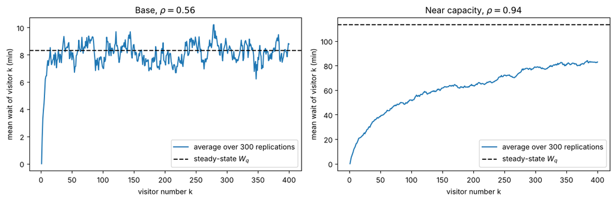

```python
base_curve = base_waits.mean(axis=0)        # NEW: axis=0 averages DOWN the rows: one mean per visitor number
near_curve = near_waits.mean(axis=0)
visitor_number = np.arange(1, 401)

fig, axes = plt.subplots(1, 2, figsize=(12, 4))
axes[0].plot(visitor_number, base_curve, label="average over 300 replications")
axes[0].axhline(mm1_theory(5.0, 9.0)["W_q"], color="black", linestyle="--", label="steady-state $W_q$")
axes[0].set_title(r"Base, $\rho=0.56$")
axes[1].plot(visitor_number, near_curve, label="average over 300 replications")
axes[1].axhline(mm1_theory(8.5, 9.0)["W_q"], color="black", linestyle="--", label="steady-state $W_q$")
axes[1].set_title(r"Near capacity, $\rho=0.94$")
for ax in axes:
    ax.set_xlabel("visitor number k")
    ax.set_ylabel("mean wait of visitor k (min)")
    ax.legend()
plt.tight_layout()
plt.show()
```

**Remarks.**

1. Both curves start at 0: the first visitor always finds the desk empty.
2. At $\rho=0.56$ the curve reaches the $W_q$ line within a few dozen visitors and then fluctuates around it.
3. At $\rho=0.94$ the curve is **still rising** after 400 visitors (about 47 hours). Every 400-visitor run is dominated by its start-up period, so its average wait is biased **downwards** compared with $W_q$.
4. This is **bias**, not noise: averaging more replications makes the curve smoother but does not lift it to the line.

**Note.** Base curve: about 7–9 minutes from visitor 10 onwards (the average over visitors 50–400 is about 8.2, against $W_q=8.33$; the wiggles are noise from 300 replications). Near-capacity curve: about 15, 38, 52, 64 and 83 minutes at visitors 10, 50, 100, 200 and 400, still well below $W_q=113.3$.

Going further (optional): the time an M/M/1 queue needs to "forget" its start is of order $(\sqrt\mu-\sqrt\lambda)^{-2}$ hours — about 1.7 hours at $\rho=0.56$ but about 140 hours at $\lambda=8.5,\mu=9$, roughly three times longer than the 47 hours a 400-visitor run lasts. Chapter 9 turns this into practical rules (warm-up deletion).

### Demo 7b: Which question are we asking? Terminating versus steady state

Suppose the help desk is a **2-hour drop-in session**: it opens empty, accepts arrivals for 120 minutes, and then serves whoever is still waiting. The empty start is now **part of the real system**, not an artefact. This is a **terminating** simulation (Chapter 9); the long-run $W_q$ is a **steady-state** quantity.

The only change to the function is the **stopping rule** (Step 6): stop accepting arrivals at the closing time instead of after $n$ visitors, and stop the loop when arrivals have stopped and the desk is empty. The number of visitors is now random. The three changed lines are marked `# CHANGED`.

```python
def simulate_session(arrival_rate, service_rate, closing_time,
                     arrival_rng, service_rng):
    # Same as simulate_help_desk, but arrivals stop at closing_time (minutes).
    mean_gap = 60 / arrival_rate
    mean_service = 60 / service_rate

    # Step 1. Initialisation
    t, N = 0.0, 0
    N_A, N_D = 0, 0
    t_A = arrival_rng.exponential(mean_gap)
    if t_A > closing_time:             # CHANGED: nobody may arrive at all
        t_A = np.inf
    t_D = np.inf
    arrival, service, start, end = [], [], [], []

    # Step 6. Stopping rule
    while t_A < np.inf or N > 0:       # CHANGED: arrivals over, desk empty
        # Step 2. Determine next event
        if t_A < t_D:
            # Step 3. Arrival event
            t = t_A
            N = N + 1
            N_A = N_A + 1
            arrival.append(t)
            t_A = t + arrival_rng.exponential(mean_gap)
            if t_A > closing_time:     # CHANGED: no arrivals after closing
                t_A = np.inf
            if N == 1:
                service_time = service_rng.exponential(mean_service)
                t_D = t + service_time
                start.append(t)
                service.append(service_time)
        else:
            # Step 4. Departure event
            t = t_D
            N = N - 1
            N_D = N_D + 1
            end.append(t)
            if N > 0:
                service_time = service_rng.exponential(mean_service)
                t_D = t + service_time
                start.append(t)
                service.append(service_time)
            else:
                t_D = np.inf

    visits = pd.DataFrame({"arrival": arrival, "service": service, "start": start, "end": end})
    visits["wait"] = visits["start"] - visits["arrival"]
    return visits
```

```python
session_rows = []
for name, (lam, mu) in [("Base", (5.0, 9.0)), ("Near capacity", (8.5, 9.0))]:
    session_waits = []
    session_sizes = []
    for seed in range(1, 201):                              # 200 independent sessions
        arrival_rng, service_rng = make_streams(seed)
        visits = simulate_session(lam, mu, 120, arrival_rng, service_rng)
        if len(visits) > 0:                                 # a session with no visitors has no average wait
            session_waits.append(visits["wait"].mean())
            session_sizes.append(len(visits))
    session_waits = np.array(session_waits)
    half_width = 1.96 * session_waits.std(ddof=1) / np.sqrt(len(session_waits))
    session_rows.append({
        "scenario": name,
        "mean visitors per session": np.mean(session_sizes),
        "mean of session average waits": session_waits.mean(),
        "95% margin": half_width,
        "steady-state W_q": mm1_theory(lam, mu)["W_q"],
    })

pd.DataFrame(session_rows).set_index("scenario").round(2)
```

| scenario | mean visitors per session | mean of session average waits | 95% margin | steady-state W_q |
| --- | --- | --- | --- | --- |
| Base | 9.77 | 5.36 | 0.91 | 8.33 |
| Near capacity | 16.88 | 15.13 | 2.03 | 113.33 |

**Question:** At $\rho=0.94$ the 2-hour session gives an average wait of about 15 minutes, while $W_q\approx113$. Which number is "right"?

## Theory 7: Replications, confidence intervals, and common random numbers

### One replication = one observation (Chapter 7)

Visitors inside one run are **dependent**: if visitor 10 waited a long time, visitor 11 probably did too. So we cannot treat 400 waits from one run as 400 independent observations. Instead, a whole run is one observation. For replication $r$ let

$$ X_r=\text{average wait in replication } r,\qquad r=1,\dots,R . $$

Different replications use different random numbers, so $X_1,\dots,X_R$ **are** independent, and the Lab 4 machinery applies unchanged:

$$ \bar X=\frac1R\sum_{r=1}^R X_r,\qquad \bar X\pm1.96\,\frac{s_X}{\sqrt R}. $$

### What replications fix, and what they do not

|  | **Noise** (run-to-run variation) | **Bias** (systematic error) |
| --- | --- | --- |
| Example | five seeds give 49 to 116 minutes | every run starts empty and is too short to reach steady state |
| Reduced by more replications? | **yes**, like $1/\sqrt R$ | **no** |
| What the CI shows | the noise | nothing — the CI is centred on the biased value |

The interval estimates the mean of **what the simulation computes** (here: the average wait of 400 visitors from an empty start). Whether that equals the quantity you care about is a modelling question.

### Comparing two policies: paired replications

To compare policy A with policy B, run both with the **same seeds**, so replication $r$ of both policies sees the same arrivals and the same service requirements. Then analyse the differences $D_r=X_r^A-X_r^B$:

$$ \mathrm{Var}(\bar D)=\frac{\mathrm{Var}(X^A)+\mathrm{Var}(X^B)-2\,\mathrm{Cov}(X^A,X^B)}{R}. $$

Positive correlation between the paired runs makes the variance of the difference **smaller** than for independent runs. This is **common random numbers**, the same idea as the controlled cost check in the Lab 4 demo.

## Demo 8: Is a faster adviser worth it?

The manager can train the adviser so that the service rate rises from 9 to 11 per hour. Compare near capacity ($\lambda=8.5$) before and after, using **20 paired replications** (seeds 1 to 20) of 400 visitors each.

### Replication 1 by hand

```python
arrival_rng, service_rng = make_streams(1)
before_1 = simulate_help_desk(8.5, 9.0, 400, arrival_rng, service_rng)["wait"].mean()

arrival_rng, service_rng = make_streams(1)          # deliberate: the SAME seed for the second policy
after_1 = simulate_help_desk(8.5, 11.0, 400, arrival_rng, service_rng)["wait"].mean()

print(f"replication 1: before = {before_1:.2f},  after = {after_1:.2f},  difference = {before_1 - after_1:.2f}")
```

```
replication 1: before = 83.13,  after = 17.26,  difference = 65.86
```

### All 20 with a loop

```python
seeds = range(1, 21)
before_waits = []
after_waits = []

for seed in seeds:
    arrival_rng, service_rng = make_streams(seed)
    before_waits.append(simulate_help_desk(8.5, 9.0, 400, arrival_rng, service_rng)["wait"].mean())
    arrival_rng, service_rng = make_streams(seed)
    after_waits.append(simulate_help_desk(8.5, 11.0, 400, arrival_rng, service_rng)["wait"].mean())

before_waits = np.array(before_waits)
after_waits = np.array(after_waits)
print("first replication again:", before_waits[0].round(2), after_waits[0].round(2))
```

```
first replication again: 83.13 17.26
```

### A confidence interval for each policy — by hand first (as in Lab 4)

```python
R = len(before_waits)
mean_before = before_waits.mean()
sd_before = before_waits.std(ddof=1)
se_before = sd_before / np.sqrt(R)
print(f"before: mean = {mean_before:.2f}, SD = {sd_before:.2f}, SE = {se_before:.2f}, "
      f"95% CI = [{mean_before - 1.96 * se_before:.2f}, {mean_before + 1.96 * se_before:.2f}]")
```

```
before: mean = 50.82, SD = 25.08, SE = 5.61, 95% CI = [39.83, 61.81]
```

```python
def mean_confidence_interval(values, z=1.96):
    # Approximate CI for the mean: mean +/- z * s / sqrt(n)  (the Lab 4 function).
    values = np.asarray(values)
    mean = values.mean()
    sample_sd = values.std(ddof=1)
    standard_error = sample_sd / np.sqrt(len(values))
    return mean, sample_sd, standard_error, mean - z * standard_error, mean + z * standard_error


policy_rows = []
for name, waits, mu in [("Before, service rate 9", before_waits, 9.0), ("After, service rate 11", after_waits, 11.0)]:
    mean, sample_sd, standard_error, lower, upper = mean_confidence_interval(waits)
    policy_rows.append({"policy": name, "mean_average_wait": mean, "sample_sd": sample_sd,
                        "lower": lower, "upper": upper, "theory_W_q": mm1_theory(8.5, mu)["W_q"]})

policy_table = pd.DataFrame(policy_rows).set_index("policy")
policy_table.round(2)
```

| policy | mean_average_wait | sample_sd | lower | upper | theory_W_q |
| --- | --- | --- | --- | --- | --- |
| Before, service rate 9 | 50.82 | 25.08 | 39.83 | 61.81 | 113.33 |
| After, service rate 11 | 16.09 | 5.41 | 13.72 | 18.46 | 18.55 |

**Question:** The "before" interval does not contain $W_q\approx113$. Should we add more replications until it does?

### The paired differences

```python
differences = before_waits - after_waits
mean_d, sd_d, se_d, lower_d, upper_d = mean_confidence_interval(differences)

print(f"mean reduction in average wait : {mean_d:.2f} minutes,  95% CI [{lower_d:.2f}, {upper_d:.2f}]")
print(f"replications where it helped   : {(differences > 0).sum()} of {R}")
print(f"smallest and largest reduction : {differences.min():.2f}, {differences.max():.2f}")
print(f"correlation between paired runs: {np.corrcoef(before_waits, after_waits)[0, 1]:.2f}")   # NEW: np.corrcoef gives the correlation matrix
```

```
mean reduction in average wait : 34.73 minutes,  95% CI [25.44, 44.03]
replications where it helped   : 20 of 20
smallest and largest reduction : 9.04, 93.43
correlation between paired runs: 0.77
```

### Compare: the same comparison with *independent* seeds

```python
independent_after = []
for seed in range(1001, 1021):                      # different seeds for the second policy
    arrival_rng, service_rng = make_streams(seed)
    independent_after.append(simulate_help_desk(8.5, 11.0, 400, arrival_rng, service_rng)["wait"].mean())
independent_after = np.array(independent_after)

se_independent = np.sqrt(before_waits.var(ddof=1) / R + independent_after.var(ddof=1) / R)
print(f"paired      : SE of the difference = {se_d:.2f}")
print(f"independent : SE of the difference = {se_independent:.2f}")
```

```
paired      : SE of the difference = 4.74
independent : SE of the difference = 5.70
```

**Note.** Before: about 50.8 minutes, CI about [39.8, 61.8], against $W_q=113.3$. After: about 16.1 minutes, CI about [13.7, 18.5], against $W_q=18.5$. Mean paired reduction about 34.7 minutes; the faster adviser helps in 20 of 20 replications, by between about 9 and 93 minutes.

The paired SE (about 4.7) is smaller than the independent SE (about 5.7), but not dramatically. The paired runs are strongly correlated (about 0.77), but the "before" runs vary far more than the "after" runs (SD about 25 against 5), so the covariance term can remove only part of the variance. Common random numbers *reduce* the noise in a comparison; they do not eliminate it.

20 of 20 is partly structural: with the same seeds, a faster service rate shortens every service time, and that can never increase anyone's wait.

### Why two streams? A synchronisation check

With **one** generator for everything, gaps and service times are drawn in the order the events happen. Change the service rate and the events happen in a different order, so visitor $k$ no longer receives the same gap. Count how many visitors get a different arrival time under the two policies, and look at the rows where the difference starts.

```python
one_rng = np.random.default_rng(DEMO_SEED)
shared_before = simulate_help_desk(8.5, 9.0, 400, one_rng, one_rng)      # the SAME generator passed twice
one_rng = np.random.default_rng(DEMO_SEED)
shared_after = simulate_help_desk(8.5, 11.0, 400, one_rng, one_rng)

arrival_rng, service_rng = make_streams(DEMO_SEED)
two_before = simulate_help_desk(8.5, 9.0, 400, arrival_rng, service_rng)
arrival_rng, service_rng = make_streams(DEMO_SEED)
two_after = simulate_help_desk(8.5, 11.0, 400, arrival_rng, service_rng)

shared_differs = ~np.isclose(shared_before["arrival"], shared_after["arrival"])   # NEW: ~ flips True/False
two_differs = ~np.isclose(two_before["arrival"], two_after["arrival"])
first = np.argmax(shared_differs)                    # NEW: np.argmax of a True/False array = position of the first True

print(f"one stream : arrival times differ for {shared_differs.sum()} of 400 visitors, starting at visitor {first + 1}")
print(f"two streams: arrival times differ for {two_differs.sum()} of 400 visitors")
pd.DataFrame({
    "one stream: before": shared_before["arrival"],
    "one stream: after": shared_after["arrival"],
    "two streams: before": two_before["arrival"],
    "two streams: after": two_after["arrival"],
}).iloc[first - 2: first + 3].round(2)
```

```
one stream : arrival times differ for 393 of 400 visitors, starting at visitor 8
two streams: arrival times differ for 0 of 400 visitors
```

|  | one stream: before | one stream: after | two streams: before | two streams: after |
| --- | --- | --- | --- | --- |
| 5 | 9.10 | 9.10 | 26.04 | 26.04 |
| 6 | 12.87 | 12.87 | 31.69 | 31.69 |
| 7 | 14.06 | 27.57 | 49.11 | 49.11 |
| 8 | 28.75 | 29.26 | 61.07 | 61.07 |
| 9 | 30.45 | 30.05 | 62.39 | 62.39 |

With one stream the arrival times agree only until the two runs process their events in a different order; after that almost every visitor has a different arrival time, so the "controlled" comparison is no longer controlled. With two streams the arrivals are identical; only the service times are rescaled.

**Lab link:** Lab 5's `simulate_mm1` generates **all** gaps first and **all** service times second. That fixes visitor $i$'s draws in advance, which is why reusing a seed there gives a properly paired comparison.

### The bug to avoid: resetting the streams inside every replication

```python
buggy_waits = []
for seed in seeds:
    arrival_rng, service_rng = make_streams(DEMO_SEED)      # BUG: the same seed in every replication
    buggy_waits.append(simulate_help_desk(8.5, 9.0, 400, arrival_rng, service_rng)["wait"].mean())

print("20 'different' replications:", np.round(buggy_waits[:5], 2), "...")
print("sample SD:", np.std(buggy_waits, ddof=1))
```

```
20 'different' replications: [23.34 23.34 23.34 23.34 23.34] ...
sample SD: 0.0
```

Twenty identical runs, SD 0, so the "confidence interval" has width 0: fake certainty. Resetting once per **policy** (with the same list of seeds) is deliberate and correct; resetting to one fixed seed in every **replication** is a bug.

## Demo 9: A strong interpretation

The evidence (help desk, $\lambda=8.5$ per hour, 20 paired replications of 400 visitors):

|  | Service rate 9 | Service rate 11 |
| --- | --- | --- |
| mean of run average waits | about 51 min | about 16 min |
| 95% CI | about [40, 62] | about [14, 18] |
| steady-state $W_q$ | 113 min | 18.5 min |
| paired reduction |  | about 35 min, CI about [25, 44], 20 of 20 replications |

> Under this model, training the adviser to serve 11 instead of 9 visitors per hour would cut the average wait at peak demand from about 51 to about 16 minutes, and the reduction appears in every paired replication. I would recommend it if the training can actually reach that service rate, which should be checked by timing real services after a pilot. The absolute waits come from 400-visitor runs that start empty; for continuous operation at this load the true long-run wait would be higher, while for a short drop-in session it would be lower, so the size of the effect depends on which situation the desk is really in. The model also assumes exponential times, a constant arrival rate, and visitors who never give up.

A strong recommendation connects:

1. the **size of the effect** and its confidence interval;
2. how **consistent** the effect is across paired replications;
3. whether the run matches the real question (**terminating or steady state**);
4. **model limitations**;
5. a practical **next action**.

## Final theory map

**Rates and means:** $\mathbb E[\text{gap}]=60/\lambda$ minutes, $\mathbb E[\text{service}]=60/\mu$ minutes; `rng.exponential(scale=mean)`.

**Event scheduling (Chapter 7 pseudocode):** 1 initialise $(t,N,t_A,t_D)=(0,0,\text{first gap},\infty)$; 2 next event is the smaller of $t_A$ and $t_D$; 3 arrival: $N\leftarrow N+1$, $t_A\leftarrow t+\text{gap}$, and if $N=1$ schedule a departure; 4 departure: $N\leftarrow N-1$, schedule the next completion if $N>0$, else $t_D=\infty$; 5 record; 6 repeat until the stopping rule.

**FCFS shortcut (one server):** $$ \texttt{start}_i=\max(\texttt{arrival}_i,\texttt{end}_{i-1}),\qquad \texttt{end}_i=\texttt{start}_i+\texttt{service}_i . $$

**Stability and steady state:** $\rho=\lambda/\mu<1$; $$ \mathbb E[N]=\frac{\rho}{1-\rho},\qquad W=\frac1{\mu-\lambda},\qquad W_q=\frac{\rho}{\mu-\lambda}. $$

**Replications:** one run = one observation $X_r$; $\bar X\pm1.96\,s_X/\sqrt R$.

### Distinctions to leave with

| This … | … is not this |
| --- | --- |
| a gap (duration) | an arrival time (clock time) |
| a rate $\lambda$ per hour | a mean $60/\lambda$ minutes |
| one run's average wait | the expected wait |
| the mean of a 400-visitor run from empty | the steady-state $W_q$ |
| noise (shrinks with more replications) | bias (does not) |
| a terminating question (a session, a rush) | a steady-state question (long run) |
| resetting the seed once per policy (controlled comparison) | resetting it in every replication (bug) |

## Final coding map

```
Rates per hour  ->  means in minutes                 mean_gap = 60 / arrival_rate        (Demo 1)
    ↓
One event by hand                                     t, N, t_A, t_D                      (Demo 2)
    ↓
The general rule (if arrival ... else departure)      copied for events 3 and 4
    ↓
while loop over events (Steps 5-6)                    event_log, then counters N_A, N_D and records
    ↓
Function                                              simulate_help_desk(..., arrival_rng, service_rng)
    ↓
Check against the FCFS shortcut                       start = max(arrival, previous_end)  (Demo 3)
    ↓
Output measures                                       wait, utilisation, event history    (Demo 4)
    ↓
Compare with theory                                   mm1_theory, scenario table          (Demos 5-6)
    ↓
Repeat the whole run                                  seeds, waits_by_visitor             (Demo 7)
    ↓
Paired replications, CI                               mean_confidence_interval            (Demo 8)
```

## Before you start Lab 5

You should now be able to explain:

1. why a DES jumps from event to event, and what the state $(t,N,t_A,t_D)$ is;
2. why `rng.exponential` needs `60 / rate`, and what goes wrong if you pass the rate;
3. why $t_A$ is "now plus a gap", not just a gap;
4. why `start = max(arrival, previous_end)` gives the same times as the event list for one FCFS server;
5. how waiting time, utilisation and queue length are defined, and which conventions you chose;
6. what $\rho$ and $W_q$ mean, and why there is no steady state when $\rho\ge1$;
7. why one run is not a decision, and why a run from empty differs from steady state;
8. what replications fix and what they do not;
9. why the same seeds are used for both policies in a comparison.

In Lab 5 you write the FCFS recursion yourself (Part B), compute the output measures (Part C), compare scenarios with $W_q$ (Part D), and run paired replications for the manager (Part E).

## Common errors

- Passing the hourly rate as NumPy's `scale` (Demo 1).
- Setting the next arrival to a gap instead of the current time plus a gap.
- Using interarrival gaps as arrival times (forgetting the cumulative sum or "$t$ +").
- Letting service start before arrival, or before the previous visitor has left.
- Counting the visitor in service as "waiting" without saying so.
- Calling a finite overloaded run stable because it finishes.
- Treating the 400 waits inside one run as independent observations.
- Expecting more replications to remove the gap between a run from empty and $W_q$.
- Comparing policies with different seeds, or with one shared stream whose draws get out of step.
- Resetting the generator to the same seed in every replication.
- Making a decision from one random run.